# R with R studio: An introduction

### Packages

R consists of a **core** set of in-built functions which can be supplemented with **additional** packages. Packages are collections of R functions, data, and compiled code, with a well-defined format that ensures easy installation and a basic standard set of documentation, enabling portability and reliability.

Here, we will use the `tidyverse` package, which is highly recommended for manipulating data structures.

```r
# Normally, you would have to install a package the first time you want to use it. There is
# a function for this, called "install.packages()", for example:
# install.packages("tidyverse")
# We have already installed tidyverse on the VM for you, so you do not need to do this (hence,
# it is commented with a #).

# Once a package has been installed, to access it, you will need to use the "library()" function
# to load the package each time you start R and want to use it:
library(tidyverse)
```

### Data import

In this exercise, we will be using helminth prevalence data downloaded from the Global Atlas of Helminth Infection (GAHI; http://www.thiswormyworld.org ). There will be three files which are available to download from the Github page.

- `Ascaris_prevalence_data.txt`
- `Hookworms prevalence_data.txt`
- `Schisoma_mansoni_prevalence_data.txt`

They are text files where each column of data is separated by **tab**, i.e., a **tab delimiter**. This allows R to know how data is separated in each column. Note that there are different types of delimiters, and that these often cause problems with getting data in R in the first place if not correctly set or formatted correctly in the data. Worth paying attention to this in your own data, and for ease, try sticking to one type.

Let’s get started. First we are going to download and read the `Ascaris_prevalence.txt` file into R from GitHub using the `read_delim` function in R. We need to tell R that is it tab delimited. Once it’s read successfully, the file will be a `tibble` format, which allows a lot of nice functions to act on it.

```r
ascaris_data_url <- 'https://github.com/WGCAdvancedCourses/Helminths_2021/raw/main/manuals/module_5_R/Ascaris_prevalence_data.txt'
ascaris_data <- read_delim(file = ascaris_data_url, delim ="\t")

# Success! You should have read some messages!
# Now ascaris is a tibble
ascaris_data
```

```
## # A tibble: 989 × 13
##    Region Country ISO_code ADM1  Latit…¹ Longi…² Year_…³ Year_…⁴ Age_s…⁵ Age_end
##    <chr>  <chr>   <chr>    <chr>   <dbl>   <dbl>   <dbl>   <dbl>   <dbl>   <dbl>
##  1 Africa Angola  AO       Bengo   -8.59    13.6    2010    2010       0      80
##  2 Africa Angola  AO       Bengo   -8.63    13.7    2010    2010       0      80
##  3 Africa Angola  AO       Bengo   -8.61    13.6    2010    2010       0      80
##  4 Africa Angola  AO       Bengo   -8.62    14.2    2010    2010       0      80
##  5 Africa Angola  AO       Bengo   -8.53    13.7    2010    2010       0      80
##  6 Africa Angola  AO       Bengo   -8.60    13.6    2010    2010       0      80
##  7 Africa Angola  AO       Bengo   -8.63    14.0    2010    2010       0      80
##  8 Africa Angola  AO       Bengo   -8.62    13.8    2010    2010       0      80
##  9 Africa Angola  AO       Bengo   -8.64    14.0    2010    2010       0      80
## 10 Africa Angola  AO       Bengo   -8.60    13.6    2010    2010       0      80
## # … with 979 more rows, 3 more variables: Individuals_surveyed <dbl>,
## #   Number_Positives <dbl>, Prevalence <dbl>, and abbreviated variable names
## #   ¹Latitude, ²Longitude, ³Year_start, ⁴Year_end, ⁵Age_start
```

```r
# What columns does the table have?
colnames(ascaris_data)
```

```
##  [1] "Region"               "Country"              "ISO_code"
##  [4] "ADM1"                 "Latitude"             "Longitude"
##  [7] "Year_start"           "Year_end"             "Age_start"
## [10] "Age_end"              "Individuals_surveyed" "Number_Positives"
## [13] "Prevalence"
```

```r
# A quick tip is you can select one column using the $ symbol
# The result will be a vector containing all the values from the selected column
# In the example below we are selecting the Country column from ascaris_data
ascaris_data$Country
```

### Data tranformation

In this section, you are going to learn five key `dplyr` functions that allow you to solve the vast majority of your data manipulation challenges:

- Pick observations by their values (`filter()`).
- Reorder the rows (`arrange()`).
- Pick variables by their names (`select()`).
- Create new variables with functions of existing variables (`mutate()`).
- Collapse many values down to a single summary (`summarise()`).

These can all be used in conjunction with a sixth function - `group_by()` - which changes the scope of each function from operating on the entire dataset to operating on it group-by-group. Overall, these functions provide the verbs for a language of data manipulation. ([R4DS](https://r4ds.had.co.nz/introduction.html))

#### Filtering

`filter()` allows you to subset observations based on their values. The first argument is the name of the data frame. The second and subsequent arguments are the expressions that filter the tibble.

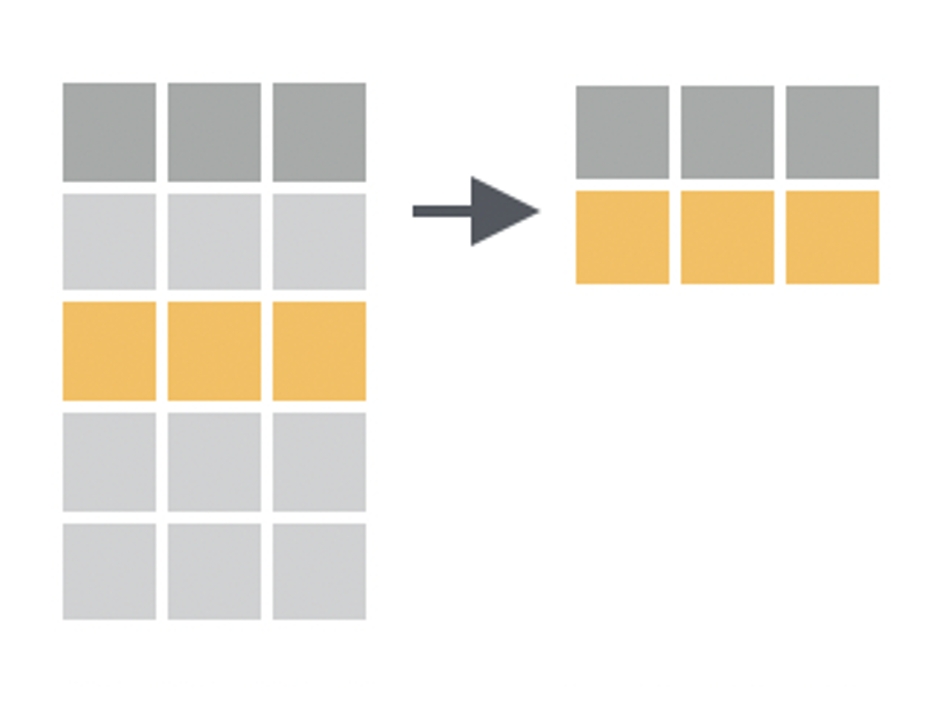

**Figure 6** - A schematic diagram of `filter()`

```r
# Let's filter our data based on the region "Africa". Here, we use the logical operator "==" to
# find all words equal to "Africa" in the "Region" column
filter(ascaris_data, Region == "Africa")
```

```
## # A tibble: 856 × 13
##    Region Country ISO_code ADM1  Latit…¹ Longi…² Year_…³ Year_…⁴ Age_s…⁵ Age_end
##    <chr>  <chr>   <chr>    <chr>   <dbl>   <dbl>   <dbl>   <dbl>   <dbl>   <dbl>
##  1 Africa Angola  AO       Bengo   -8.59    13.6    2010    2010       0      80
##  2 Africa Angola  AO       Bengo   -8.63    13.7    2010    2010       0      80
##  3 Africa Angola  AO       Bengo   -8.61    13.6    2010    2010       0      80
##  4 Africa Angola  AO       Bengo   -8.62    14.2    2010    2010       0      80
##  5 Africa Angola  AO       Bengo   -8.53    13.7    2010    2010       0      80
##  6 Africa Angola  AO       Bengo   -8.60    13.6    2010    2010       0      80
##  7 Africa Angola  AO       Bengo   -8.63    14.0    2010    2010       0      80
##  8 Africa Angola  AO       Bengo   -8.62    13.8    2010    2010       0      80
##  9 Africa Angola  AO       Bengo   -8.64    14.0    2010    2010       0      80
## 10 Africa Angola  AO       Bengo   -8.60    13.6    2010    2010       0      80
## # … with 846 more rows, 3 more variables: Individuals_surveyed <dbl>,
## #   Number_Positives <dbl>, Prevalence <dbl>, and abbreviated variable names
## #   ¹Latitude, ²Longitude, ³Year_start, ⁴Year_end, ⁵Age_start
```

```r
# Note that there are different logical orerators that can be used to filter your data in many
# different ways. Also note the previous command only displays the output, which is normal when
# you are trying to explore different functions and options.

# In order to save the output, you need to redirect the output into a new tibble.
ascaris.africa <- filter(ascaris_data, Region == "Africa")

ascaris.africa
```

```
## # A tibble: 856 × 13
##    Region Country ISO_code ADM1  Latit…¹ Longi…² Year_…³ Year_…⁴ Age_s…⁵ Age_end
##    <chr>  <chr>   <chr>    <chr>   <dbl>   <dbl>   <dbl>   <dbl>   <dbl>   <dbl>
##  1 Africa Angola  AO       Bengo   -8.59    13.6    2010    2010       0      80
##  2 Africa Angola  AO       Bengo   -8.63    13.7    2010    2010       0      80
##  3 Africa Angola  AO       Bengo   -8.61    13.6    2010    2010       0      80
##  4 Africa Angola  AO       Bengo   -8.62    14.2    2010    2010       0      80
##  5 Africa Angola  AO       Bengo   -8.53    13.7    2010    2010       0      80
##  6 Africa Angola  AO       Bengo   -8.60    13.6    2010    2010       0      80
##  7 Africa Angola  AO       Bengo   -8.63    14.0    2010    2010       0      80
##  8 Africa Angola  AO       Bengo   -8.62    13.8    2010    2010       0      80
##  9 Africa Angola  AO       Bengo   -8.64    14.0    2010    2010       0      80
## 10 Africa Angola  AO       Bengo   -8.60    13.6    2010    2010       0      80
## # … with 846 more rows, 3 more variables: Individuals_surveyed <dbl>,
## #   Number_Positives <dbl>, Prevalence <dbl>, and abbreviated variable names
## #   ¹Latitude, ²Longitude, ³Year_start, ⁴Year_end, ⁵Age_start
```

```r
# We can also select for multiple conditions within our data by using "%in%". In this case, we
# want to select samples from Ghana AND Malawi. Note we are using the "c" function as we have
# done previously.
ascaris.GhanaAndMalawi <- filter(ascaris_data,Country %in% c("Ghana", "Malawi"))
ascaris.GhanaAndMalawi
```

```
## # A tibble: 110 × 13
##    Region Country ISO_code ADM1  Latit…¹ Longi…² Year_…³ Year_…⁴ Age_s…⁵ Age_end
##    <chr>  <chr>   <chr>    <chr>   <dbl>   <dbl>   <dbl>   <dbl>   <dbl>   <dbl>
##  1 Africa Ghana   GH       Asha…    7.30  -1.69     2008    2008       9      18
##  2 Africa Ghana   GH       Cent…    5.13  -1.20     2008    2008       8      16
##  3 Africa Ghana   GH       Cent…    5.52  -1.33     2008    2008       8      15
##  4 Africa Ghana   GH       Cent…    5.58  -1.47     2008    2008       8      17
##  5 Africa Ghana   GH       Nort…    9.08  -1.83     2008    2008      10      18
##  6 Africa Ghana   GH       Asha…    6.59  -1.86     2008    2008      10      15
##  7 Africa Ghana   GH       Uppe…   11.0   -0.484    2008    2008      11      19
##  8 Africa Ghana   GH       Asha…    6.58  -1.12     2008    2008       9      18
##  9 Africa Ghana   GH       Nort…    8.47  -2.17     2008    2008       8      18
## 10 Africa Ghana   GH       Nort…    9.68   0.173    2008    2008       7      18
## # … with 100 more rows, 3 more variables: Individuals_surveyed <dbl>,
## #   Number_Positives <dbl>, Prevalence <dbl>, and abbreviated variable names
## #   ¹Latitude, ²Longitude, ³Year_start, ⁴Year_end, ⁵Age_start
```

```r
# Sometimes, we want to exclude certain data. Add a "!" in front of your argument means we want
# all the rows with the Country EXCEPT Angola.
ascaris.NotAngola <- filter(ascaris_data,! Country == "Angola")
ascaris.NotAngola
```

```
## # A tibble: 951 × 13
##    Region Country ISO_code ADM1  Latit…¹ Longi…² Year_…³ Year_…⁴ Age_s…⁵ Age_end
##    <chr>  <chr>   <chr>    <chr>   <dbl>   <dbl>   <dbl>   <dbl>   <dbl>   <dbl>
##  1 Africa Burundi BI       Buru…   -3.86    29.5    2007    2007      10      16
##  2 Africa Burundi BI       Cibi…   -2.84    29.3    2007    2007      10      16
##  3 Africa Burundi BI       Ngozi   -2.84    29.7    2007    2007      10      16
##  4 Africa Burundi BI       Buba…   -3.16    29.4    2007    2007      10      16
##  5 Africa Burundi BI       Buju…   -3.42    29.4    2007    2007      10      16
##  6 Africa Burundi BI       Mwaro   -3.53    29.7    2007    2007      10      16
##  7 Africa Burundi BI       Maka…   -4.20    29.7    2007    2007      10      16
##  8 Africa Burundi BI       Muyi…   -2.90    30.4    2007    2007      10      16
##  9 Africa Burundi BI       Kiru…   -2.53    30.4    2007    2007      10      16
## 10 Africa Burundi BI       Cank…   -3.23    30.6    2007    2007      10      16
## # … with 941 more rows, 3 more variables: Individuals_surveyed <dbl>,
## #   Number_Positives <dbl>, Prevalence <dbl>, and abbreviated variable names
## #   ¹Latitude, ²Longitude, ³Year_start, ⁴Year_end, ⁵Age_start
```

```r
# Similarly, instead of the "!" in front of Country, we could have also used "!=" which indicates
# "does not equal".
ascaris.NotAngola <- filter(ascaris_data, Country != "Angola")
ascaris.NotAngola
```

```
## # A tibble: 951 × 13
##    Region Country ISO_code ADM1  Latit…¹ Longi…² Year_…³ Year_…⁴ Age_s…⁵ Age_end
##    <chr>  <chr>   <chr>    <chr>   <dbl>   <dbl>   <dbl>   <dbl>   <dbl>   <dbl>
##  1 Africa Burundi BI       Buru…   -3.86    29.5    2007    2007      10      16
##  2 Africa Burundi BI       Cibi…   -2.84    29.3    2007    2007      10      16
##  3 Africa Burundi BI       Ngozi   -2.84    29.7    2007    2007      10      16
##  4 Africa Burundi BI       Buba…   -3.16    29.4    2007    2007      10      16
##  5 Africa Burundi BI       Buju…   -3.42    29.4    2007    2007      10      16
##  6 Africa Burundi BI       Mwaro   -3.53    29.7    2007    2007      10      16
##  7 Africa Burundi BI       Maka…   -4.20    29.7    2007    2007      10      16
##  8 Africa Burundi BI       Muyi…   -2.90    30.4    2007    2007      10      16
##  9 Africa Burundi BI       Kiru…   -2.53    30.4    2007    2007      10      16
## 10 Africa Burundi BI       Cank…   -3.23    30.6    2007    2007      10      16
## # … with 941 more rows, 3 more variables: Individuals_surveyed <dbl>,
## #   Number_Positives <dbl>, Prevalence <dbl>, and abbreviated variable names
## #   ¹Latitude, ²Longitude, ³Year_start, ⁴Year_end, ⁵Age_start
```

*Exercises*  
1. Can you create a `tibble` that contains all the rows except those from `Senegal` and `Philippines`?  
2. Can you create a `tibble` with all sites with a `prevalence` greater than 0.5?

#### Select

It’s not uncommon to get datasets with hundreds or even thousands of variables. In this case, the first challenge is often narrowing in on the variables you’re actually interested in. `select()` allows you to rapidly zoom in on a useful subset using operations based on the names of the variables.

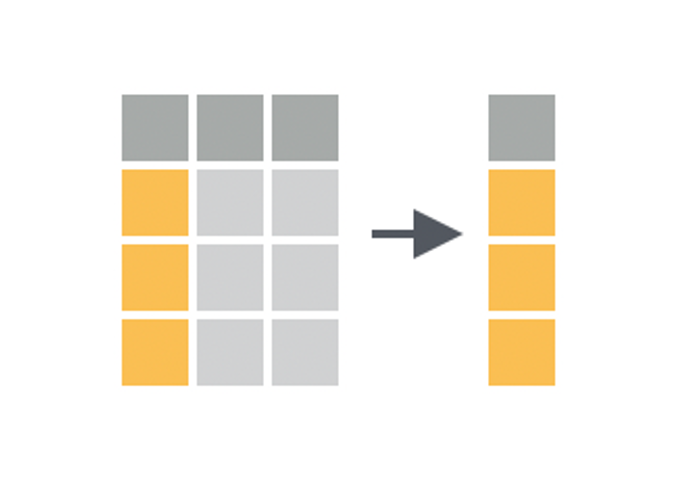

**Figure 7** - A schematic diagram of `select()`

```r
# Lets subset the data to extract Country and Prevalence
select(ascaris_data, Country, Prevalence)
```

```
## # A tibble: 989 × 2
##    Country Prevalence
##    <chr>        <dbl>
##  1 Angola      0.143
##  2 Angola      0.167
##  3 Angola      0.0964
##  4 Angola      0.381
##  5 Angola      0.0952
##  6 Angola      0.05
##  7 Angola      0.170
##  8 Angola      0
##  9 Angola      0.0635
## 10 Angola      0.677
## # … with 979 more rows
```

#### Mutate

Besides selecting sets of existing columns, it’s often useful to add new columns that are functions of existing columns. That’s the job of `mutate()`.

mutate() always adds new columns at the end of your dataset, so we’ll start by creating a narrower dataset so we can see the new variables. Remember that when you’re in RStudio, the easiest way to see all the columns is View().

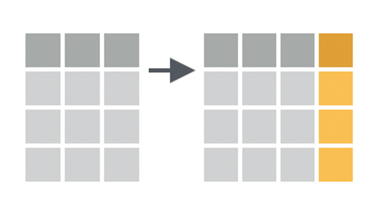

**Figure 8** - A schematic diagram of `mutate()`

```r
# The prevalence is determined by dividing the number of positive infection cases by the total
# number of individuals tested.

ascaris_data_check <- mutate(ascaris_data, Prevalence_2 = Number_Positives /  Individuals_surveyed)
ascaris_data_check
```

```
## # A tibble: 989 × 14
##    Region Country ISO_code ADM1  Latit…¹ Longi…² Year_…³ Year_…⁴ Age_s…⁵ Age_end
##    <chr>  <chr>   <chr>    <chr>   <dbl>   <dbl>   <dbl>   <dbl>   <dbl>   <dbl>
##  1 Africa Angola  AO       Bengo   -8.59    13.6    2010    2010       0      80
##  2 Africa Angola  AO       Bengo   -8.63    13.7    2010    2010       0      80
##  3 Africa Angola  AO       Bengo   -8.61    13.6    2010    2010       0      80
##  4 Africa Angola  AO       Bengo   -8.62    14.2    2010    2010       0      80
##  5 Africa Angola  AO       Bengo   -8.53    13.7    2010    2010       0      80
##  6 Africa Angola  AO       Bengo   -8.60    13.6    2010    2010       0      80
##  7 Africa Angola  AO       Bengo   -8.63    14.0    2010    2010       0      80
##  8 Africa Angola  AO       Bengo   -8.62    13.8    2010    2010       0      80
##  9 Africa Angola  AO       Bengo   -8.64    14.0    2010    2010       0      80
## 10 Africa Angola  AO       Bengo   -8.60    13.6    2010    2010       0      80
## # … with 979 more rows, 4 more variables: Individuals_surveyed <dbl>,
## #   Number_Positives <dbl>, Prevalence <dbl>, Prevalence_2 <dbl>, and
## #   abbreviated variable names ¹Latitude, ²Longitude, ³Year_start, ⁴Year_end,
## #   ⁵Age_start
```

```r
# There's a lot of columns so it's difficult to visualise them
# Let's select only the two columns Prevalence and Prevalence_2 to check if the calculations are consistent.
select(ascaris_data_check, Prevalence, Prevalence_2)
```

```
## # A tibble: 989 × 2
##    Prevalence Prevalence_2
##         <dbl>        <dbl>
##  1     0.143        0.143
##  2     0.167        0.167
##  3     0.0964       0.0964
##  4     0.381        0.381
##  5     0.0952       0.0952
##  6     0.05         0.05
##  7     0.170        0.170
##  8     0            0
##  9     0.0635       0.0635
## 10     0.677        0.677
## # … with 979 more rows
```

*Exercise*  
Can you make a new column called `study_time`, and in it, determine the number of years that sampling took place?  
*Hint*: you could could calculate the difference between `Year_end` and `Year_start`. Try to name save the result in a new `tibble` as it is often good practice to keep raw data (table) and save the processed data into new variables / tibbles.

#### Arrange

`arrange()` works similarly to `filter()` except that instead of selecting rows, it changes their order. It takes a data frame and a set of column names (or more complicated expressions) to order by. If you provide more than one column name, each additional column will be used to break ties in the values of preceding columns:

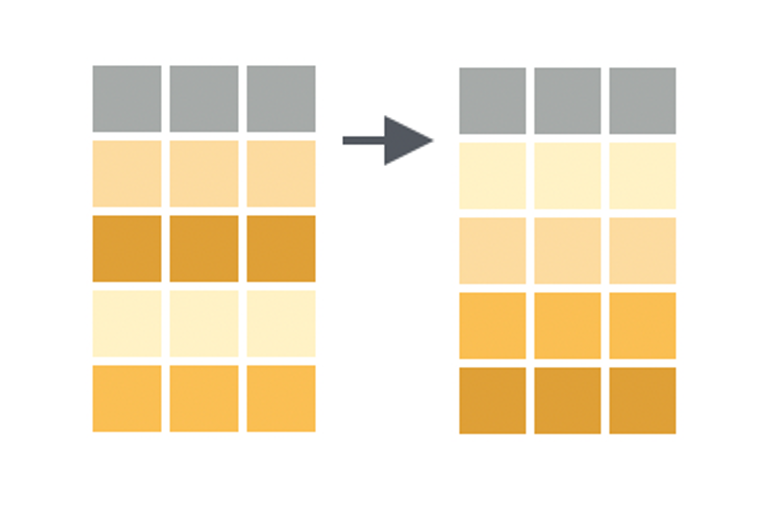

**Figure 9** - A schematic diagram of `arrange()`

```r
# First, lets arrange the data by parasite prevalence in ascending order
arrange(ascaris_data, Prevalence)
```

```
## # A tibble: 989 × 13
##    Region Country ISO_code ADM1  Latit…¹ Longi…² Year_…³ Year_…⁴ Age_s…⁵ Age_end
##    <chr>  <chr>   <chr>    <chr>   <dbl>   <dbl>   <dbl>   <dbl>   <dbl>   <dbl>
##  1 Africa Angola  AO       Bengo   -8.62    13.8    2010    2010       0      80
##  2 Africa Angola  AO       Bengo   -8.39    13.8    2010    2010       0      80
##  3 Africa Angola  AO       Bengo   -8.53    13.7    2010    2010       0      80
##  4 Africa Angola  AO       Bengo   -8.54    13.9    2010    2010       0      80
##  5 Africa Angola  AO       Bengo   -8.64    13.8    2010    2010       0      80
##  6 Africa Angola  AO       Bengo   -8.63    14.0    2010    2010       0      80
##  7 Africa Angola  AO       Bengo   -8.44    13.8    2010    2010       0      80
##  8 Africa Burundi BI       Buru…   -3.86    29.5    2007    2007      10      16
##  9 Africa Burundi BI       Cibi…   -2.78    29.1    2007    2007      10      16
## 10 Africa Burundi BI       Maka…   -4.30    29.6    2007    2007      10      16
## # … with 979 more rows, 3 more variables: Individuals_surveyed <dbl>,
## #   Number_Positives <dbl>, Prevalence <dbl>, and abbreviated variable names
## #   ¹Latitude, ²Longitude, ³Year_start, ⁴Year_end, ⁵Age_start
```

```r
# Use desc() to re-order by a column in descending order:
arrange(ascaris_data, desc(Prevalence))
```

```
## # A tibble: 989 × 13
##    Region  Country ISO_c…¹ ADM1  Latit…² Longi…³ Year_…⁴ Year_…⁵ Age_s…⁶ Age_end
##    <chr>   <chr>   <chr>   <chr>   <dbl>   <dbl>   <dbl>   <dbl>   <dbl>   <dbl>
##  1 East a… Philip… PH      "Reg…   16.0   120.      2000    2000       5       7
##  2 East a… China   CN      "Yun…   21.8   100.      2006    2006       4      99
##  3 Africa  Uganda  UG      "Kis…   -1.34   29.8     2005    2005       5      16
##  4 Africa  Nigeria NG      "Ogu…    6.44    4.41    2003    2005       5      16
##  5 Africa  Nigeria NG      "Ogu…    7.23    3.53    2003    2005       5      16
##  6 Africa  Uganda  UG      "Kis…   -1.19   29.7     2005    2005       5      16
##  7 East a… Philip… PH      " "     14.4   121.      2000    2000       5       7
##  8 East a… Philip… PH      "Reg…   16.0   120.      2000    2000       5       7
##  9 East a… Philip… PH      "Reg…   15.3   121.      2000    2000       5       7
## 10 Africa  Uganda  UG      "Kab…   -1.23   29.9     2006    2006       1      50
## # … with 979 more rows, 3 more variables: Individuals_surveyed <dbl>,
## #   Number_Positives <dbl>, Prevalence <dbl>, and abbreviated variable names
## #   ¹ISO_code, ²Latitude, ³Longitude, ⁴Year_start, ⁵Year_end, ⁶Age_start
```

```r
# We can also sort on two columns. The order in which they sorted is based on the order in which
# they are plced in the command.
arrange(ascaris_data, Country, Prevalence)
```

```
## # A tibble: 989 × 13
##    Region Country ISO_code ADM1  Latit…¹ Longi…² Year_…³ Year_…⁴ Age_s…⁵ Age_end
##    <chr>  <chr>   <chr>    <chr>   <dbl>   <dbl>   <dbl>   <dbl>   <dbl>   <dbl>
##  1 Africa Angola  AO       Bengo   -8.62    13.8    2010    2010       0      80
##  2 Africa Angola  AO       Bengo   -8.39    13.8    2010    2010       0      80
##  3 Africa Angola  AO       Bengo   -8.53    13.7    2010    2010       0      80
##  4 Africa Angola  AO       Bengo   -8.54    13.9    2010    2010       0      80
##  5 Africa Angola  AO       Bengo   -8.64    13.8    2010    2010       0      80
##  6 Africa Angola  AO       Bengo   -8.63    14.0    2010    2010       0      80
##  7 Africa Angola  AO       Bengo   -8.44    13.8    2010    2010       0      80
##  8 Africa Angola  AO       Bengo   -8.52    13.7    2010    2010       0      80
##  9 Africa Angola  AO       Bengo   -8.57    13.5    2010    2010       0      80
## 10 Africa Angola  AO       Bengo   -8.39    13.7    2010    2010       0      80
## # … with 979 more rows, 3 more variables: Individuals_surveyed <dbl>,
## #   Number_Positives <dbl>, Prevalence <dbl>, and abbreviated variable names
## #   ¹Latitude, ²Longitude, ³Year_start, ⁴Year_end, ⁵Age_start
```

#### Group_by and Summarise

The last key verb is summarise(). It collapses a data frame to a single row.

Together, `group_by()` and `summarise()` will allow you to produce **grouped summaries**, one of the more useful features of dplyr and one you will likely use a lot.

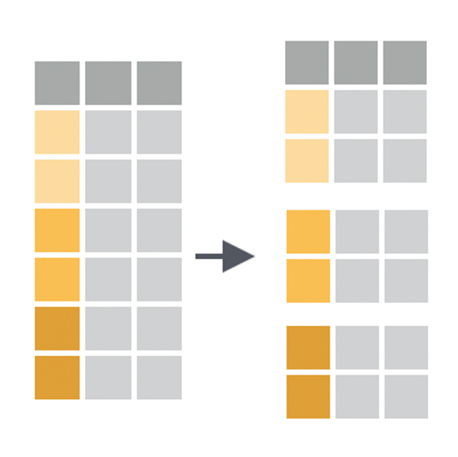

**Figure 10** - A schematic diagram of `group_by()`

```r
# let's group the studies by Country, and save it into another tibble by_country
by_country <- group_by(ascaris_data, Country)

# examine the dataset to see what's the difference

by_country
```

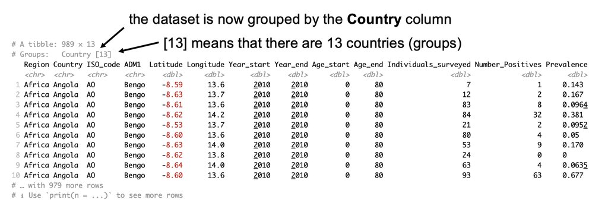

**Figure 11** - Closer inspection of `by_country`

`summarise()` collapses a data frame to a single row and do calculations depending on the given function. It will be very useful if you pair the function with `group_by()`. Then, when you use the dplyr verbs on a grouped data frame they’ll be automatically applied “by group”. For example, if we applied exactly the same code to a data frame grouped by country, we get the average Prevalence by country

```r
# average prevalence of all studies in the dataset
# you get a number but this may not be as informative
summarise(ascaris_data, average.Prevalence = mean(Prevalence) )
```

```
## # A tibble: 1 × 1
##   average.Prevalence
##                <dbl>
## 1              0.102
```

This one number is the mean of Prevalence across entire studies, which may not be very informative if we were looking at regional differences. Hence we do the following:

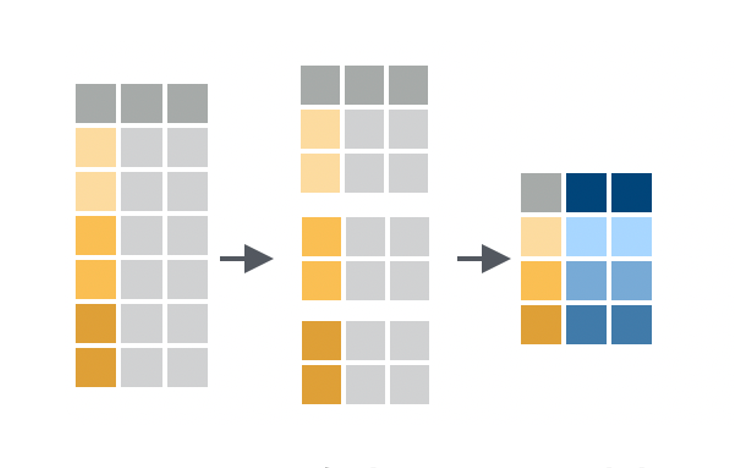

**Figure 12** - A schematic diagram of `group_by()` and `summarise()`

```r
# now we want to get the mean prevalence of each study for each country
summarise(by_country, average.Prevalence = mean(Prevalence) )
```

```
## # A tibble: 13 × 2
##    Country       average.Prevalence
##    <chr>                      <dbl>
##  1 Angola                   0.123
##  2 Burundi                  0.155
##  3 Cameroon                 0.592
##  4 China                    0.926
##  5 Cote D'Ivoire            0.051
##  6 Eritrea                  0.00188
##  7 Ghana                    0.0226
##  8 Malawi                   0.0127
##  9 Nigeria                  0.443
## 10 Philippines              0.283
## 11 Senegal                  0.0942
## 12 Sierra Leone             0.0710
## 13 Uganda                   0.0633
```

Grouped summaries, generated using `group_by()` and `summarise()`, provide a really useful tool for exploring data when working with dplyr. But before we go any further with this, we need to introduce a powerful new idea: the **pipe**.